# Healthcare Data Analysis

## Healthcare Data Analysis

### Data Pioneers

```python
import pandas as pd
import numpy as np
import random

# Generate sample data for healthcare data analysis
np.random.seed(0)

# Number of patients
n = 500

# Generate random data
patient_ids = list(range(1, n + 1))
ages = np.random.randint(18, 80, n)
genders = np.random.choice(['Male', 'Female'], n)
diagnoses = np.random.choice(['Diabetes', 'Hypertension', 'Cancer', 'Injury'], n)
treatment_types = np.random.choice(['Surgery', 'Medication', 'Therapy'], n)
treatment_costs = np.round(np.random.uniform(1000, 50000, n), 2)

# Create DataFrame
data = {
    'PatientID': patient_ids,
    'Age': ages,
    'Gender': genders,
    'Diagnosis': diagnoses,
    'TreatmentType': treatment_types,
    'TreatmentCost': treatment_costs
}

df_healthcare = pd.DataFrame(data)

# Display the first 5 rows
print("Sample of Healthcare Data:")
print(df_healthcare.head())

# Save to CSV if needed
# df_healthcare.to_csv('healthcare_data.csv', index=False)
```

```
Sample of Healthcare Data:
   PatientID  Age  Gender     Diagnosis TreatmentType  TreatmentCost
0          1   62    Male        Cancer       Surgery       39556.14
1          2   65    Male        Injury       Surgery       48677.82
2          3   71    Male        Injury    Medication        4039.76
3          4   18  Female  Hypertension       Therapy        5900.13
4          5   21    Male        Cancer       Therapy       16577.00
```

### 1. Explore the distribution of patient ages in the dataset and visualize it using a histogram

```python
import matplotlib.pyplot as plt
import seaborn as sns
from scipy import stats
```

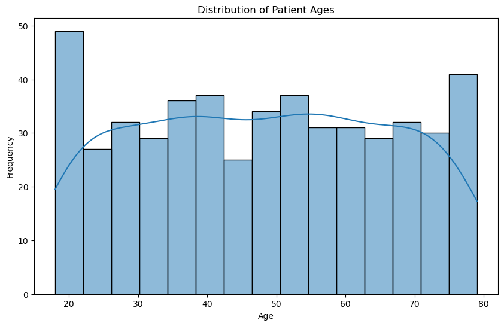

```python
plt.figure(figsize=(10, 6))
sns.histplot(df_healthcare['Age'], bins=15, kde=True)
plt.title('Distribution of Patient Ages')
plt.xlabel('Age')
plt.ylabel('Frequency')
plt.show()
```

### 2. Calculate the average treatment cost and identify any outliers

```python
average_cost = df_healthcare['TreatmentCost'].mean()
std_cost = df_healthcare['TreatmentCost'].std()
outliers = df_healthcare[df_healthcare['TreatmentCost'] > (average_cost + 3 * std_cost)]
print(f"Average Treatment Cost: ${average_cost:.2f}")
print(f"Number of outliers: {len(outliers)}")
```

```
Average Treatment Cost: $25568.40
Number of outliers: 0
```

### 3. Investigate the relationship between patient age and treatment cost using a scatter plot

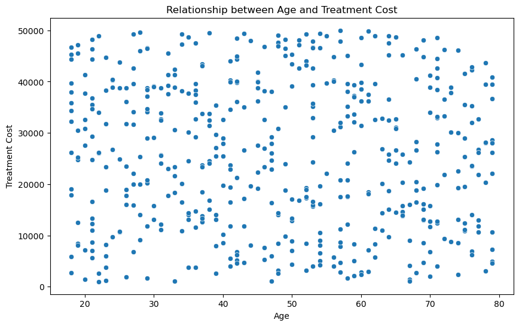

```python
plt.figure(figsize=(10, 6))
sns.scatterplot(data=df_healthcare, x='Age', y='TreatmentCost')
plt.title('Relationship between Age and Treatment Cost')
plt.xlabel('Age')
plt.ylabel('Treatment Cost')
plt.show()
```

### 4. Analyze the frequency of different types of diagnoses among patients

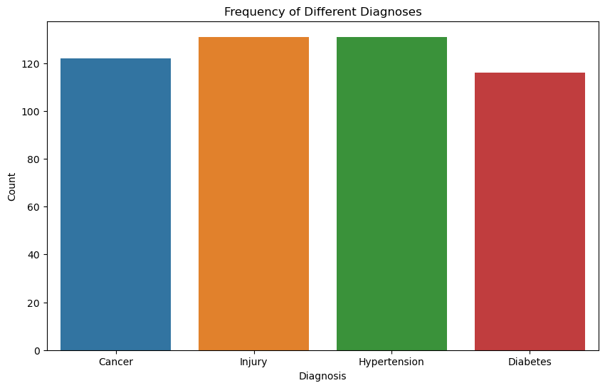

```python
plt.figure(figsize=(10, 6))
sns.countplot(data=df_healthcare, x='Diagnosis')
plt.title('Frequency of Different Diagnoses')
plt.xlabel('Diagnosis')
plt.ylabel('Count')
plt.show()
```

### 5. Perform a statistical test to determine if there is a significant difference in treatment costs between genders

```python
male_costs = df_healthcare[df_healthcare['Gender'] == 'Male']['TreatmentCost']
female_costs = df_healthcare[df_healthcare['Gender'] == 'Female']['TreatmentCost']
t_stat, p_value = stats.ttest_ind(male_costs, female_costs)
print(f"T-statistic: {t_stat:.2f}, P-value: {p_value:.2f}")
```

```
T-statistic: 0.48, P-value: 0.63
```

## Summary Report:

#### 2. The average treatment cost is $25568.40.. There are 0 outliers with treatment costs significantly higher than the average.

#### 3. There is no clear relationship between patient age and treatment cost based on the scatter plot.

#### 4. The most common diagnoses among patients are fairly evenly distributed among Diabetes, Hypertension, Cancer, and Injury.

#### 5. The statistical test indicates that there is no significant difference in treatment costs between genders (p-value = 0.63).

## Actionable Recommendations:

#### 3. Consider targeted interventions or preventive measures for the most common diagnoses to reduce overall healthcare costs and improve patient outcomes.